# Model in R.

This is intended to help get people started with initial modeling in R, by going through the main steps:

- EDA
- cleanup
- imputation
- feature engineering
- modeling
- hyperparameter tuning
- comparing models
- EDA on model errors

# Load libraries and define utility functions

This code uses ggplot2 for plotting, lubridate for some time-handing, caret as a workhorse modeling library, and car for power transformations.

A handful of utility functions are also useful.

# Macro data

The data is in three files. The macro(economic) data is something to add to both the test and the train records by joining on the timestamp. It makes more sense to do any cleanup of the macro records before joining, however, so will start with that.

## Macro EDA

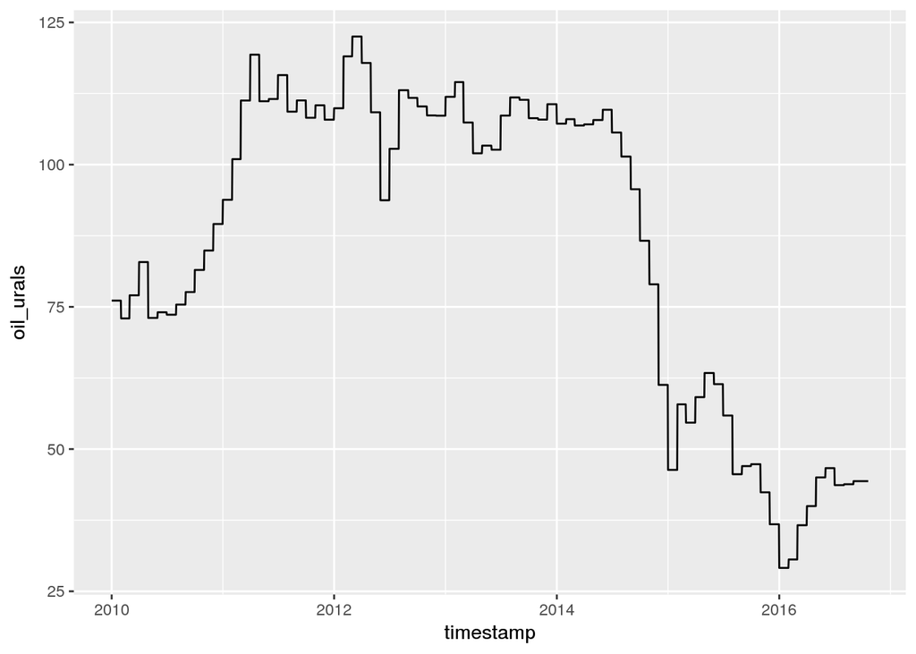

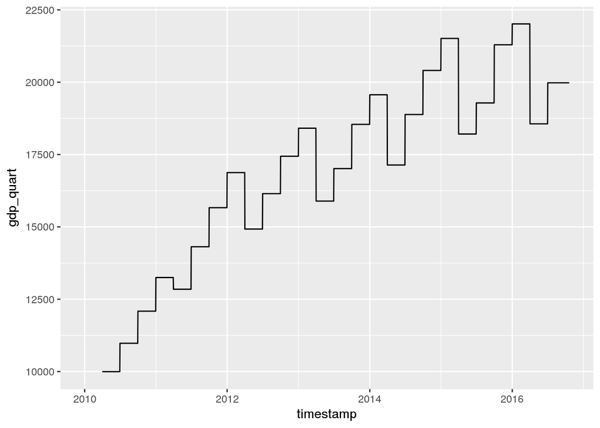

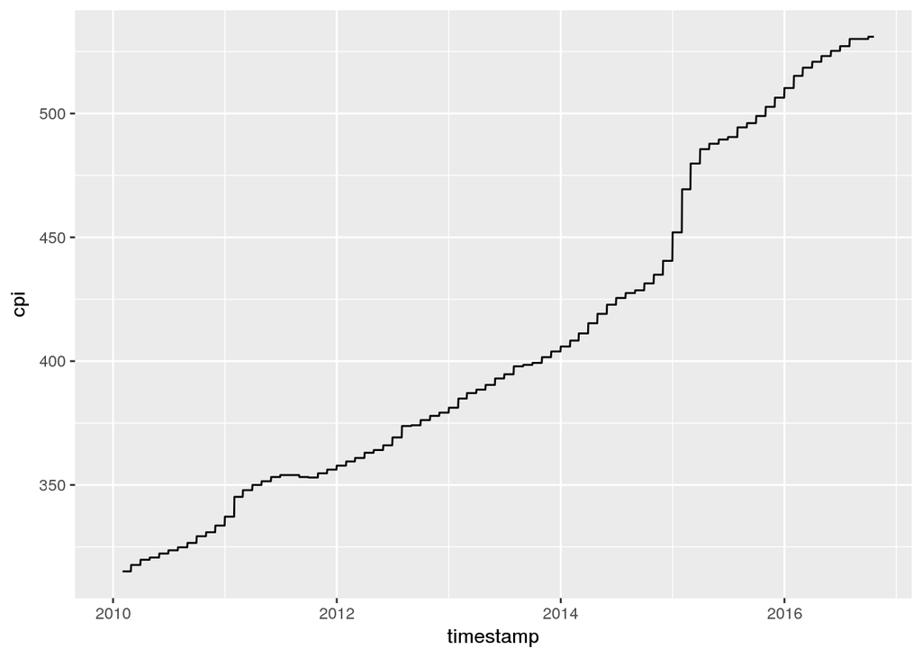

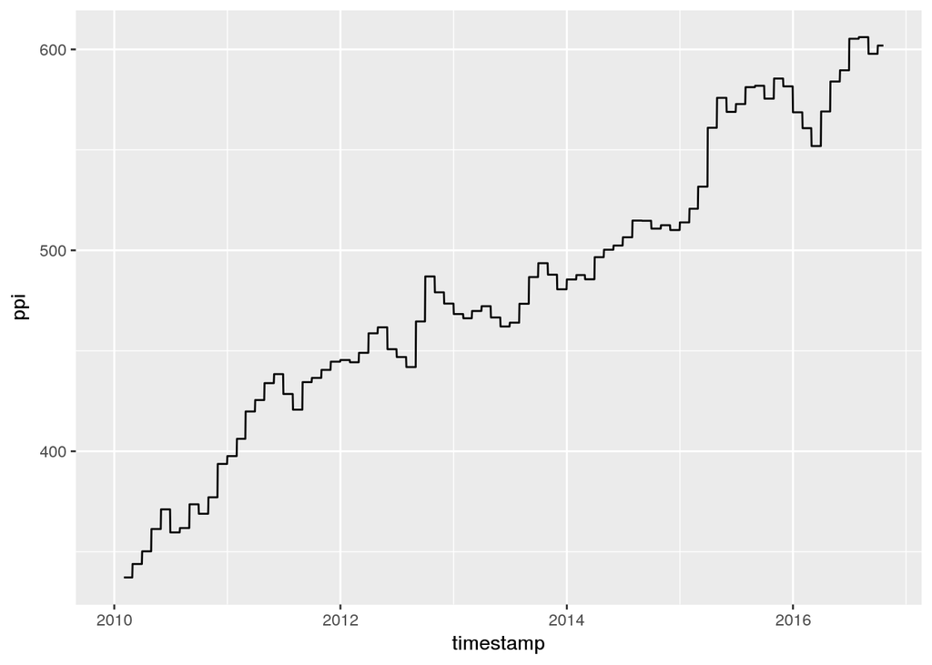

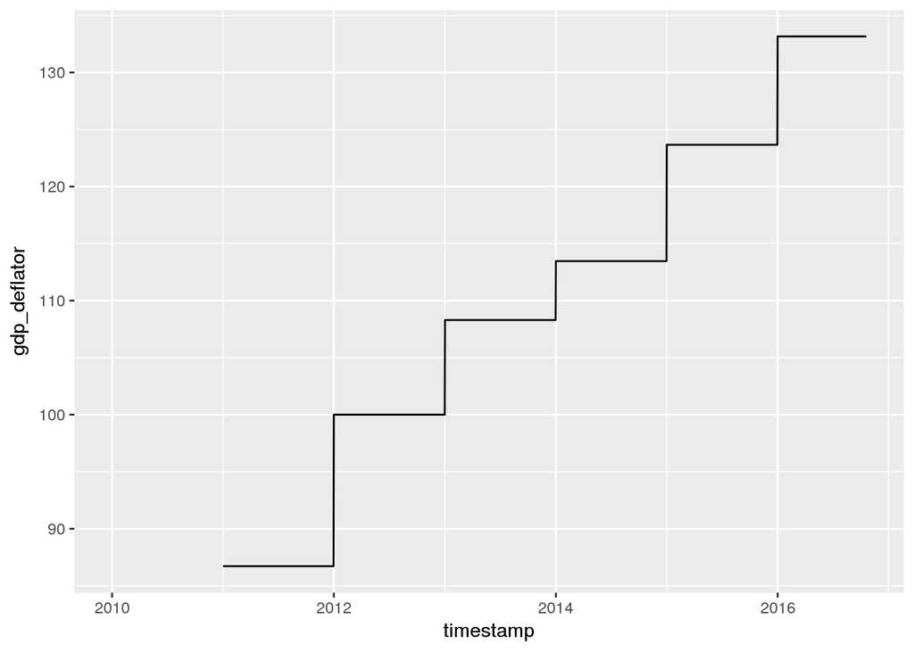

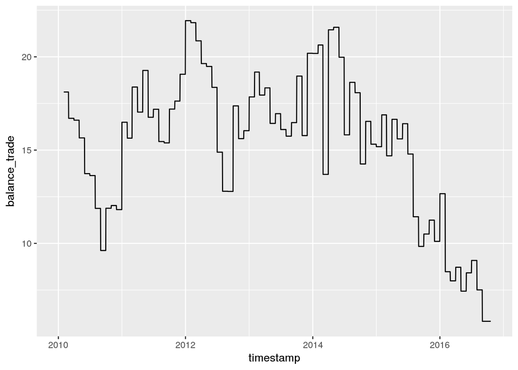

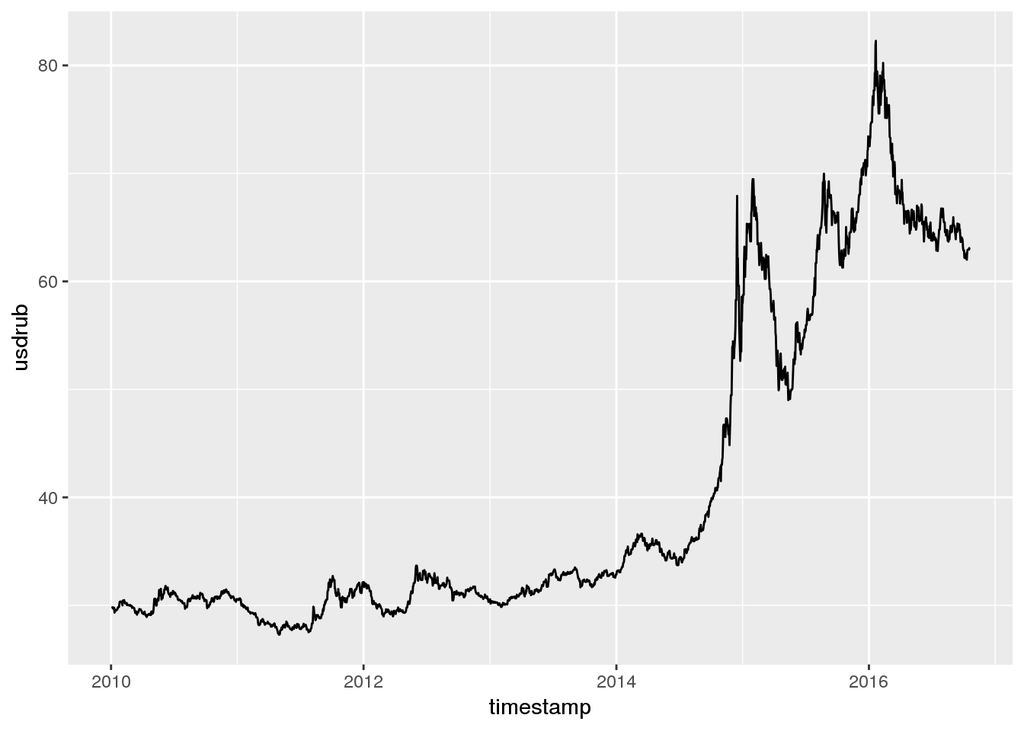

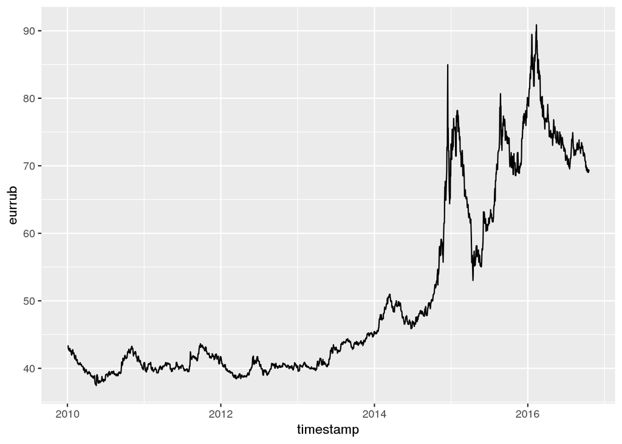

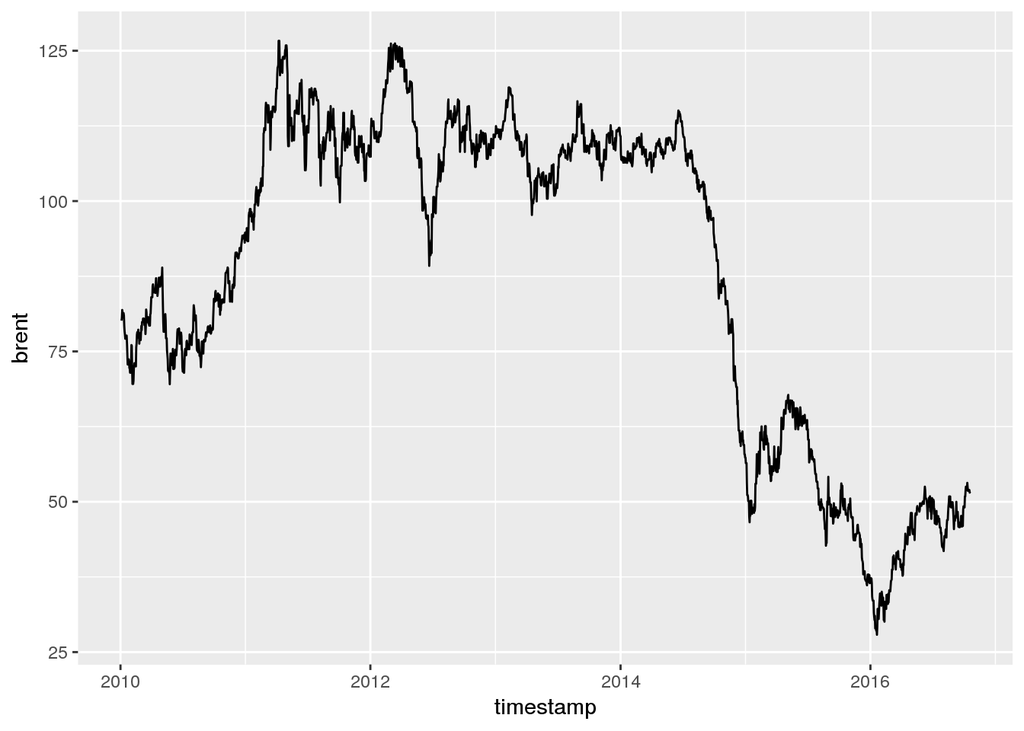

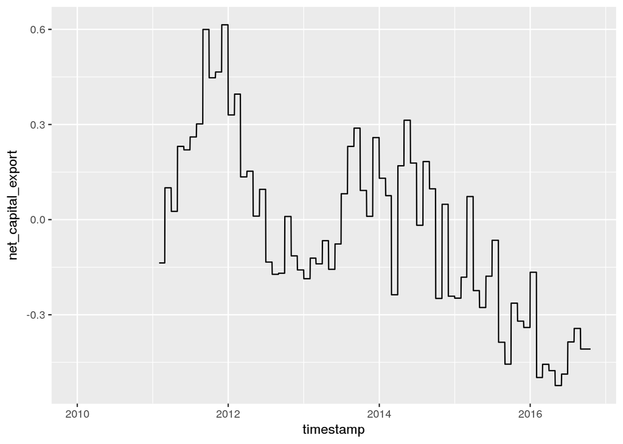

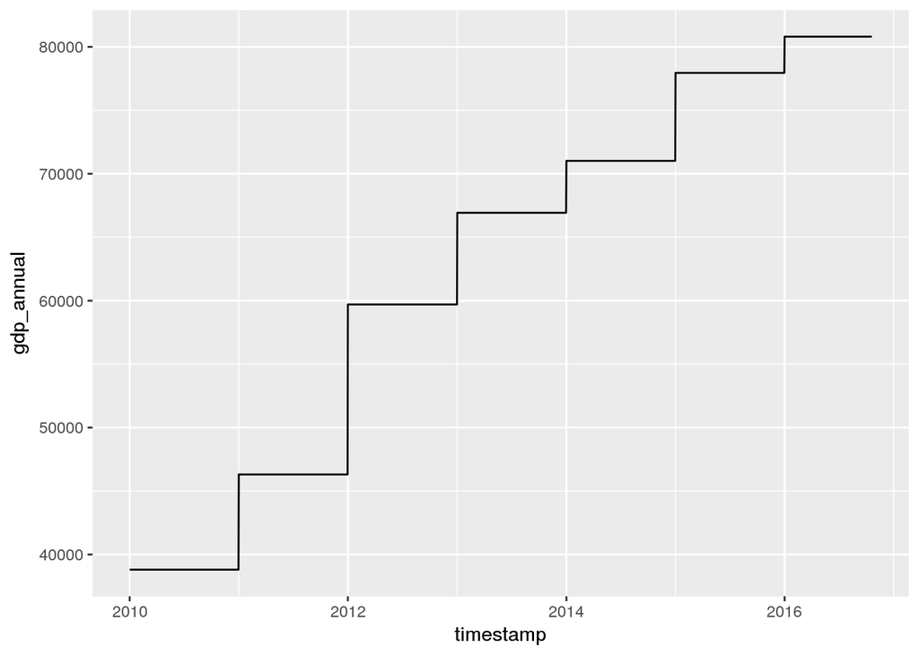

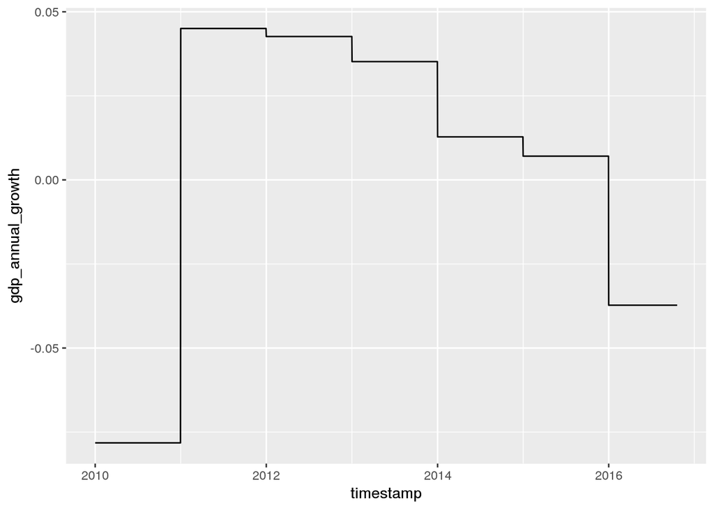

[85 more figures not shown]

## Macro fixes

Clean up mortgag value to create a new mortgage value montonic column.

Drop a handful of columns with a very small number of values that look uninteresting.

The rent price room eco data also looks like it has a suspicious value or two in it. Remove those to impute them with something more likely.

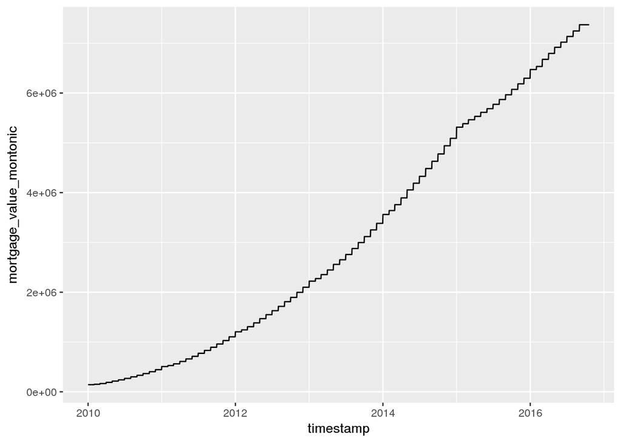

## Macro imputation

Some modeling algorithms deal poorly with missing values, so impute values where needed. Don’t want to lose the NA-ness entirely however, so add a ‘unknown’ level to factors, and a isna column for each numeric column.

```
## [1] "  add_isna_col processing gdp_quart"
## [1] "  add_isna_col processing gdp_quart_growth"
## [1] "  add_isna_col processing cpi"
## [1] "  add_isna_col processing ppi"
## [1] "  add_isna_col processing gdp_deflator"
## [1] "  add_isna_col processing balance_trade"
## [1] "  add_isna_col processing balance_trade_growth"
## [1] "  add_isna_col processing usdrub"
## [1] "  add_isna_col processing eurrub"
## [1] "  add_isna_col processing brent"
## [1] "  add_isna_col processing net_capital_export"
## [1] "  add_isna_col processing average_provision_of_build_contract_moscow"
## [1] "  add_isna_col processing rts"
## [1] "  add_isna_col processing micex"
## [1] "  add_isna_col processing micex_rgbi_tr"
```

[output cut: 67 more lines]

```
## [1] "after imputation, have 0 NAs in macro data"
```

# Load train and test data and fix column types

Load the property-specific data, and fix column types. It’s actually easiest to do this by combining test and train into one data frame, and cleaning that.

## Partition the original train data into train, validate and test

Break overall_train into three sets, train, validate and test as 60:20:20 split